# An exploration of Wine Quality by James Cooper

RESIDUAL SUGAR:

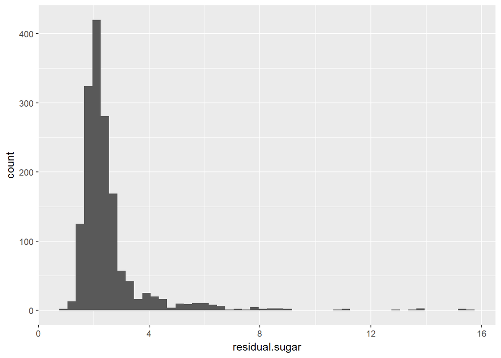

```
##    Min. 1st Qu.  Median    Mean 3rd Qu.    Max.
##   0.900   1.900   2.200   2.539   2.600  15.500
```

Distance between the third quartile and the max is massive - several high outliers. This meant the data was a good fit for the use of a transformation.

CHLORIDES:

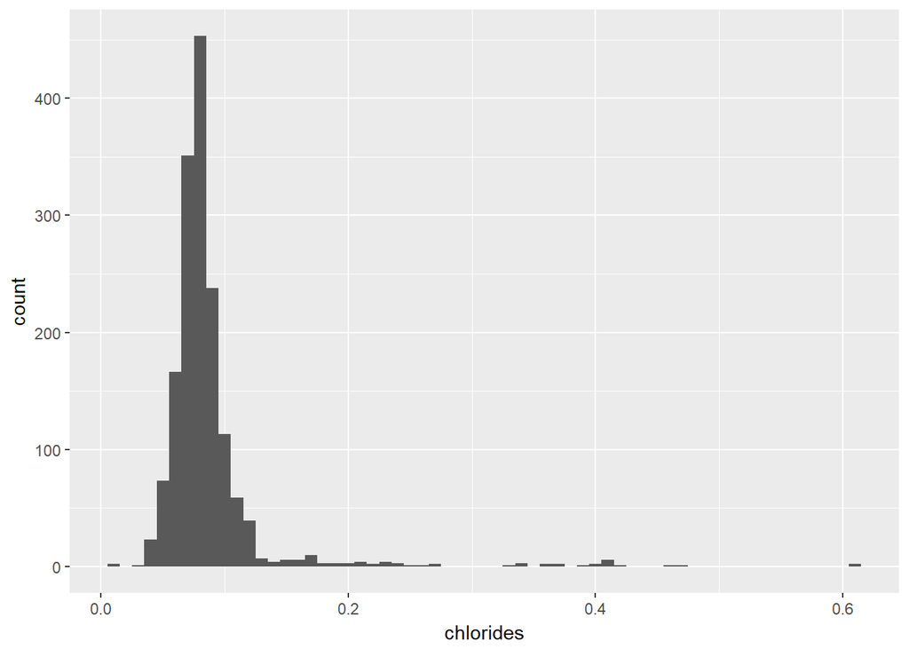

```
##    Min. 1st Qu.  Median    Mean 3rd Qu.    Max.
## 0.01200 0.07000 0.07900 0.08747 0.09000 0.61100
```

Again, large difference between the 3rd quartile and max. A few values on the low end as well - whilst visually these are not outliers, it could be worth keeping track of these results.

SULFUR DIOXIDE:

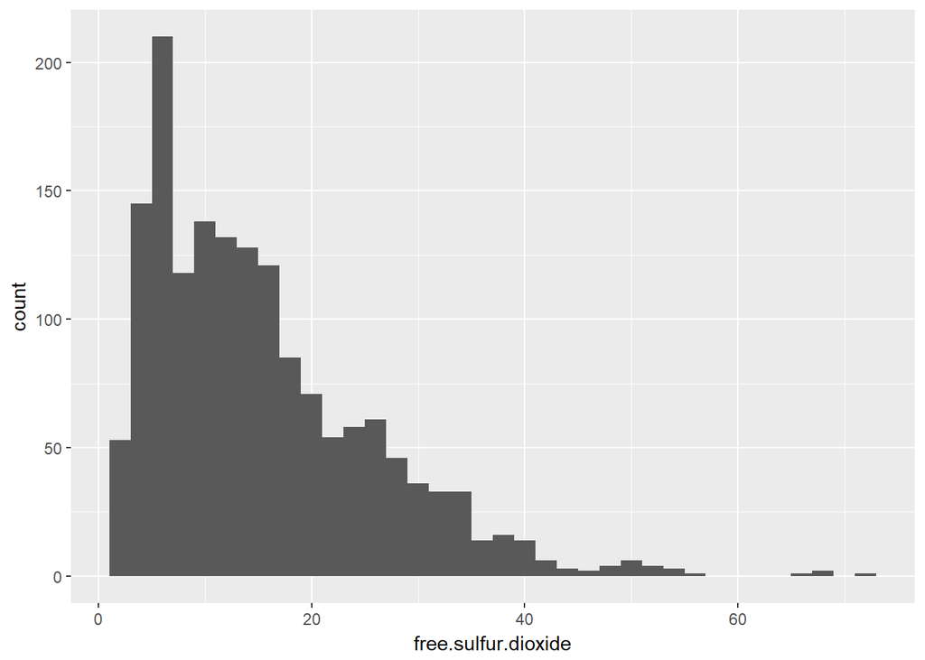

```
##    Min. 1st Qu.  Median    Mean 3rd Qu.    Max.
##    1.00    7.00   14.00   15.87   21.00   72.00
```

Yet again we can see that several outliers are present, and the familiar pattern of a large top quartile appears once again. The distribution is skewed, so lets see what taking the log does:

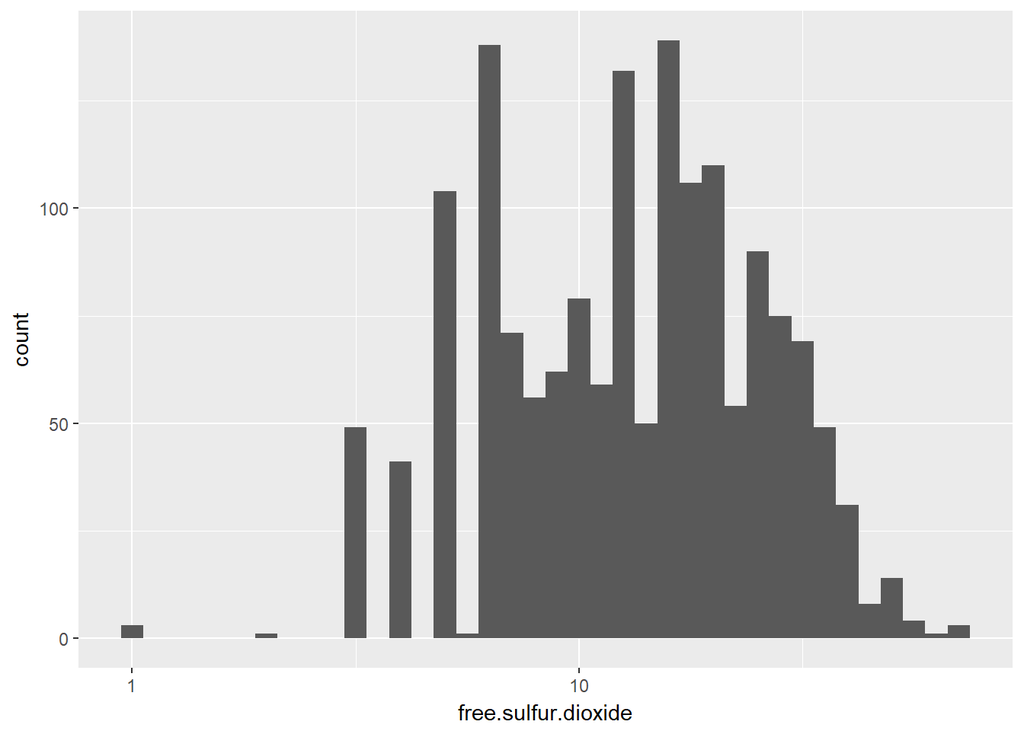

The log adjusted FS02 figures show a bimodal distribution.

TOTAL SULFUR DIOXIDE:

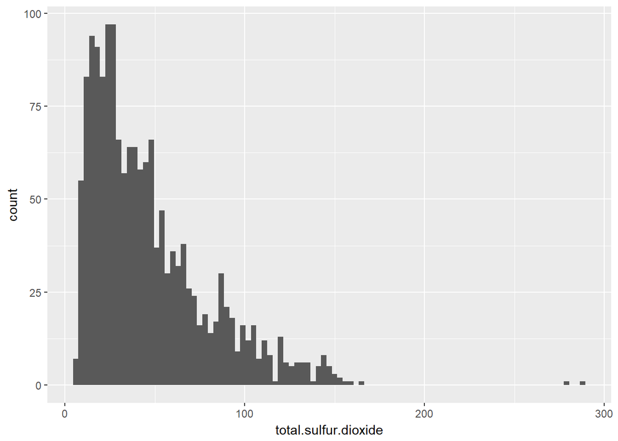

```
##    Min. 1st Qu.  Median    Mean 3rd Qu.    Max.
##    6.00   22.00   38.00   46.47   62.00  289.00
```

As above.

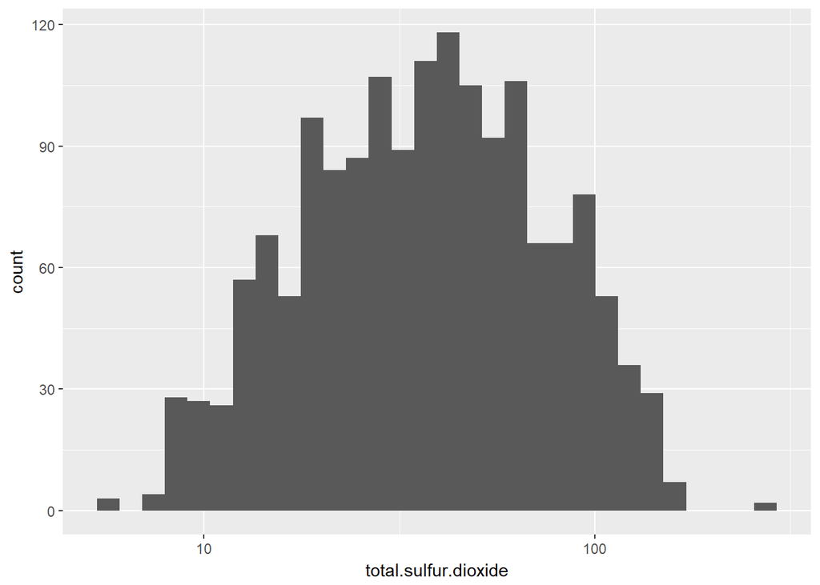

Taking the log reveals a nice normal distribution.

DENSITY:

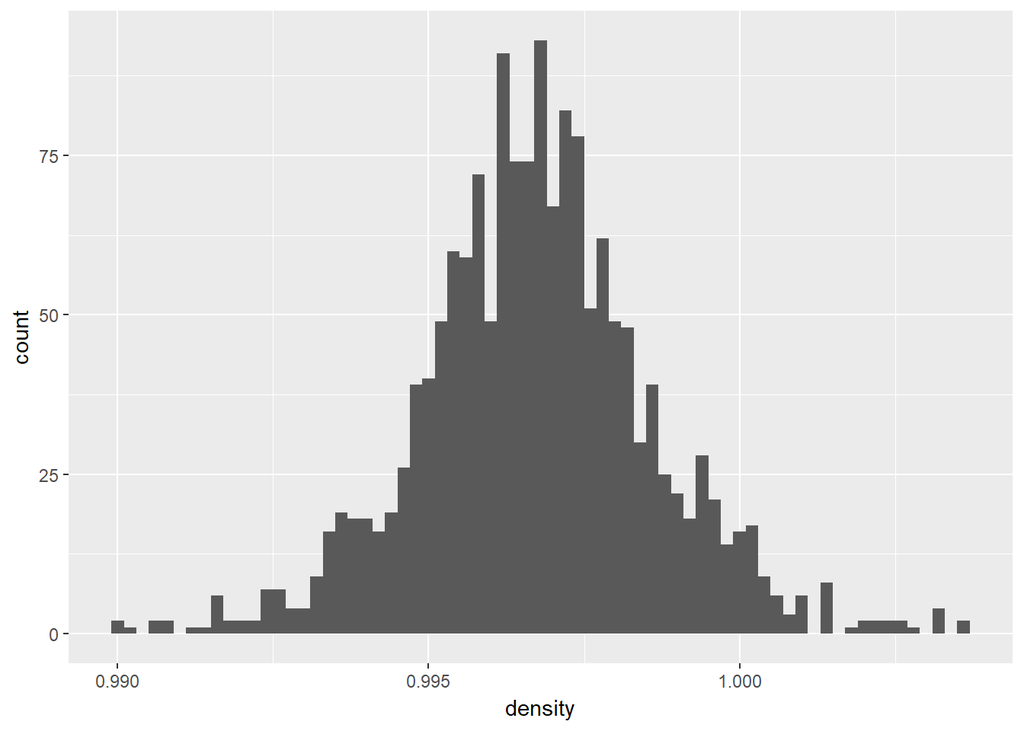

```
##    Min. 1st Qu.  Median    Mean 3rd Qu.    Max.
##  0.9901  0.9956  0.9968  0.9967  0.9978  1.0037
```